# Biomarker comparison across 8 cell lines

[John Zobolas](https://github.com/bblodfon)

## Intro

In this notebook we will compare the biomarker results from 8 different cell lines. The results were obtained through an ensemble model analysis, which was performed on the models generated by the `Gitsbe` module when running the DrugLogics computational pipeline for finding synergistic drug combinations (drug pairs). The models in each different cell line setup were trained towards a specific signaling activity profile matching the activity state of that particular cell line. For more info about **the cell line specific model & biomarker analysis, see the respective notebooks:**

- [A498](https://bblodfon.github.io/gitsbe-model-analysis/A498_model_analysis.html)
- [AGS](https://bblodfon.github.io/gitsbe-model-analysis/AGS_model_analysis.html)
- [colo205](https://bblodfon.github.io/gitsbe-model-analysis/colo205_model_analysis.html)
- [DU145](https://bblodfon.github.io/gitsbe-model-analysis/DU145_model_analysis.html)
- [MDA-MB-468](https://bblodfon.github.io/gitsbe-model-analysis/MDA-MB-468_model_analysis.html)
- [SF295](https://bblodfon.github.io/gitsbe-model-analysis/SF295_model_analysis.html)
- [SW620](https://bblodfon.github.io/gitsbe-model-analysis/SW620_model_analysis.html)
- [UACC62](https://bblodfon.github.io/gitsbe-model-analysis/UACC62_model_analysis.html)

Note that the biomarkers identified in the aforementioned notebooks, were classified as: - Performance-related biomarkers, which represent important nodes that make our models achieve a higher model performance classification (the methodology was based on the number of $TP$ (true positives) and the $MCC$ (Mathews Correlation Coefficient) score) - Per synergy predicted biomarkers, which represent important nodes that make our models predict (cell line specific) observed synergies

In each category, the biomarkers can be either in *an active state* or in *an inhibited state*. The input for the simulations and the output data are in the `cell-lines-2500` directory (the 2500 number denotes the number of simulations executed). The analysis will be presented step by step in the sections below.

## Prerequisites

Firstly, we load the required libraries (you need to install them if you don’t have them):

```r
library(superheat) # version 1.0.0, see (Barter, 2017)
```

and the relevant helper functions:

```r
# Set the working directory to the gitsbe-model-analysis folder:
# setwd("pathTo/gitsbe-model-analysis")
source("Rscripts/input_functions.R")
source("Rscripts/output_functions.R")
source("Rscripts/analysis_functions.R")
```

The R version used for this analysis is:

```r
pretty.print.string(R.version.string)
```

> R version 3.4.4 (2018-03-15)

## Input

Firstly, we define the necessary input (cell line names, directories and files of interest, etc.):

```r
cell.lines = c("A498", "AGS", "colo205", "DU145", "MDA-MB-468", "SF295",
               "SW620", "UACC62")

cell.lines.dirs = sapply(cell.lines, function(cell.line) {
  paste0(getwd(), "/cell-lines-2500/", cell.line)
})

biomarkers.dirs = sapply(cell.lines.dirs, function(cell.line.dir) {
  paste0(cell.line.dir, "/biomarkers")
})

observed.synergies.files = sapply(cell.lines.dirs, function(cell.line.dir) {
  paste0(cell.line.dir, "/observed_synergies")
})

# get the drug combinations tested
model.predictions.file = paste0(cell.lines.dirs[1], "/model_predictions")
model.predictions = get.model.predictions(model.predictions.file)
drug.combinations.tested = colnames(model.predictions)

# get the node names (same topology for all cell lines)
models.dir = paste0(cell.lines.dirs[1], "/models")
node.names = get.node.names(models.dir)
```

## Performance Biomarkers

Next, we will visualize the performance biomarkers per cell line:

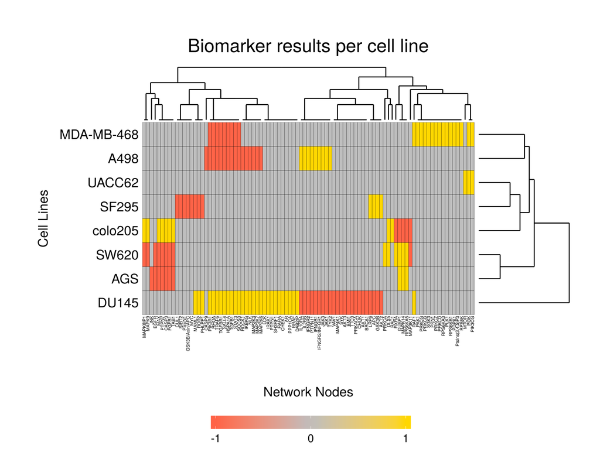

```r
biomarkers.perf.active =
  get.perf.biomarkers.per.cell.line(biomarkers.dirs, type = "active")

biomarkers.perf.inhibited =
  get.perf.biomarkers.per.cell.line(biomarkers.dirs, type = "inhibited")

biomarkers.perf.res =
  merge.perf.biomarkers(node.names, cell.lines, biomarkers.perf.active,
                        biomarkers.perf.inhibited)

# remove nodes which are not biomarkers for any cell line
biomarkers.perf.res = prune.columns.from.df(biomarkers.perf.res, value = 0)

superheat(biomarkers.perf.res, title.alignment = "center", title.size = 7,
          title = paste0("Biomarker results per cell line"),
          row.dendrogram = TRUE, col.dendrogram = TRUE, scale = FALSE,
          column.title = "Network Nodes", row.title = "Cell Lines",
          heat.pal = c("tomato", "grey", "gold"),
          # grey   = not a biomarker
          # tomato = inhibited biomarker
          # gold   = active biomarker
          force.grid.vline = TRUE, force.grid.hline = TRUE,
          grid.vline.size = 0.1, grid.hline.size = 0.1,
          legend.breaks = c(-1, 0, 1),
          left.label.col = "white", left.label.text.size = 5,
          bottom.label.col = "white",
          bottom.label.text.size = 1.7, bottom.label.text.angle = 90)
```

- Across all cell lines, a total of 91 performance biomarkers were found
- The three gastro-related cell lines (`AGS,SW620,colo205`) have a lot of common biomarkers
- In general the biomarker results are different between the cell lines
- There exist unique biomarkers per cell line which are not shared with any other cell line
- There are common biomarkers between the cell lines in either tha same activity state (`SW620` vs `AGS`) or the reverse (`SW620` vs `colo205`)

## Observed synergies

Each of the cell lines studied, has a different set of observed synergies (drug combinations that were found synergistic across all the 153 tested ones). In this section, we will visualize the cell lines’ observed synergies and mark the synergies that were also predicted by the cell-specific models:

```r
biomarkers.per.synergy = get.synergy.biomarkers.per.cell.line(biomarkers.dirs)

total.predicted.synergies = character(0)
for (cell.line in cell.lines) {
  total.predicted.synergies =
    c(total.predicted.synergies, rownames(biomarkers.per.synergy[cell.line][[1]]))
}
total.predicted.synergies = unique(total.predicted.synergies)
total.predicted.synergies.num = length(total.predicted.synergies)
```

```r
observed.synergies.per.cell.line = sapply(
  observed.synergies.files, function(observed.synergies.file) {
    get.observed.synergies(observed.synergies.file)
})

observed.synergies.res =
  merge.observed.synergies(drug.combinations.tested, cell.lines,
                           observed.synergies.per.cell.line)

# remove drug combinations which are not observed in any of the cell lines
observed.synergies.res = prune.columns.from.df(observed.synergies.res, value = 0)

total.observed.synergies = colnames(observed.synergies.res)
total.observed.synergies.num = length(total.observed.synergies)
```

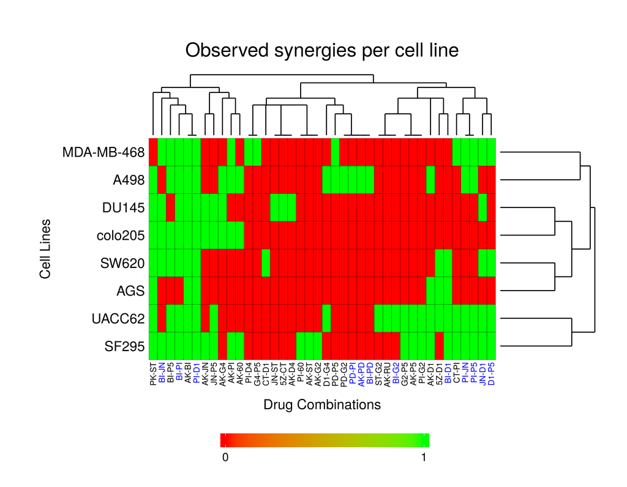

```r
# color the predicted synergies
predicted.synergies.colors = rep("black", total.observed.synergies.num)
names(predicted.synergies.colors) = total.observed.synergies
predicted.synergies.colors[total.observed.synergies %in%
                          total.predicted.synergies] = "blue"

superheat(observed.synergies.res, title.alignment = "center", title.size = 7,
          title = paste0("Observed synergies per cell line"),
          row.dendrogram = TRUE, col.dendrogram = TRUE, scale = FALSE,
          column.title = "Drug Combinations", row.title = "Cell Lines",
          heat.pal = c("red", "green"),
          # red   = non-observed synergy
          # green = observed synergy
          force.grid.vline = TRUE, force.grid.hline = TRUE,
          grid.vline.size = 0.1, grid.hline.size = 0.1,
          legend.breaks = c(0, 1),
          left.label.col = "white", left.label.text.size = 5,
          bottom.label.col = "white", bottom.label.text.col = predicted.synergies.colors,
          bottom.label.text.size = 3, bottom.label.text.angle = 90)
```

## References

1. Barter Rebecca, Yu Bin (2017) Superheat: An R package for creating beautiful and extendable heatmaps for visualizing complex data. https://arxiv.org/abs/1512.01524, https://rlbarter.github.io/superheat/